# Using infer

Bruce Hartman

University of St. Francis

2026-08-22

Abstract

We present some uses of the `infer` package.

# Packages

```r
library(infer)
library(ISLR2)
if(!("mbadtools" %in% installed.packages()))  pak::pak("bhartman2/mbadtools")
library(mbadtools) # some extra ggplot functions
library(tidymodels)
conflicted::conflict_prefer_matching("select|filter", "dplyr", quiet=TRUE)
```

# Data

```r
# load in the dataset
data(gss)

# take a glimpse at it
str(gss)
```

```
tibble [500 × 11] (S3: tbl_df/tbl/data.frame)
 $ year   : num [1:500] 2014 1994 1998 1996 1994 ...
 $ age    : num [1:500] 36 34 24 42 31 32 48 36 30 33 ...
 $ sex    : Factor w/ 2 levels "male","female": 1 2 1 1 1 2 2 2 2 2 ...
 $ college: Factor w/ 2 levels "no degree","degree": 2 1 2 1 2 1 1 2 2 1 ...
 $ partyid: Factor w/ 5 levels "dem","ind","rep",..: 2 3 2 2 3 3 1 2 3 1 ...
 $ hompop : num [1:500] 3 4 1 4 2 4 2 1 5 2 ...
 $ hours  : num [1:500] 50 31 40 40 40 53 32 20 40 40 ...
 $ income : Ord.factor w/ 12 levels "lt $1000"<"$1000 to 2999"<..: 12 11 12 12 12 12 12 12 12 10 ...
 $ class  : Factor w/ 6 levels "lower class",..: 3 2 2 2 3 3 2 3 3 2 ...
 $ finrela: Factor w/ 6 levels "far below average",..: 2 2 2 4 4 3 2 4 3 1 ...
 $ weight : num [1:500] 0.896 1.083 0.55 1.086 1.083 ...
```

# Data Description

```r
gss %>% skim
```

```
── Data Summary ────────────────────────
                           Values
Name                       Piped data
Number of rows             500
Number of columns          11
_______________________
Column type frequency:
  factor                   6
  numeric                  5
________________________
Group variables            None
```

|  | skim_variable | n_missing | complete_rate | ordered | n_unique | top_counts |
| --- | --- | --- | --- | --- | --- | --- |
| 1 | sex | 0 | 1 | FALSE | 2 | mal: 263, fem: 237 |
| 2 | college | 0 | 1 | FALSE | 2 | no : 326, deg: 174 |
| 3 | partyid | 0 | 1 | FALSE | 4 | ind: 192, dem: 177, rep: 123, oth: 8 |
| 4 | income | 0 | 1 | TRUE | 12 | $25: 303, $20: 60, $10: 49, $15: 42 |
| 5 | class | 0 | 1 | FALSE | 4 | wor: 251, mid: 209, low: 20, upp: 20 |
| 6 | finrela | 0 | 1 | FALSE | 6 | ave: 239, bel: 115, abo: 106, far: 25 |

|  | skim_variable | n_missing | complete_rate | mean | sd | p0 | p25 | p50 | p75 | p100 | hist |
| --- | --- | --- | --- | --- | --- | --- | --- | --- | --- | --- | --- |
| 1 | year | 0 | 1 | 1995.160000 | 12.5528302 | 1973.0000000 | 1985.0000000 | 1996.0000 | 2006.0000 | 2018.000000 | ▆▇▇▅▆ |
| 2 | age | 0 | 1 | 40.266000 | 13.3195369 | 18.0000000 | 29.0000000 | 38.0000 | 50.0000 | 87.000000 | ▇▇▆▂▁ |
| 3 | hompop | 0 | 1 | 2.858000 | 1.5718707 | 1.0000000 | 2.0000000 | 3.0000 | 4.0000 | 11.000000 | ▇▃▁▁▁ |
| 4 | hours | 0 | 1 | 41.382000 | 14.8199642 | 3.0000000 | 36.7500000 | 40.0000 | 48.0000 | 89.000000 | ▂▂▇▂▁ |
| 5 | weight | 0 | 1 | 1.054118 | 0.5153446 | 0.4118981 | 0.8549876 | 1.0127 | 1.0985 | 5.243926 | ▇▂▁▁▁ |

# Analysis

As an example, we’ll run an analysis of variance on age and partyid, testing whether the age of a respondent is independent of their political party affiliation.

```r
F_hat <- gss |>
  specify(age ~ partyid) |>
  calculate(stat = "F")
F_hat %>% glimpse
```

```
Rows: 1
Columns: 1
$ stat <dbl> 2.484209
```

This checks with the value of F for the linear regression of `age` on `partyid`.

```r
lm(age ~ partyid, data=gss) %>% glance() %>% pull(statistic)
```

```
   value
2.484209
```

# Null Model

Then, generating the null distribution,

```r
null_dist <- gss |>
   specify(age ~ partyid) |>
   hypothesize(null = "independence") |>
   generate(reps = 1000, type = "permute") |>
   calculate(stat = "F")
null_dist %>% glimpse
```

```
Rows: 1,000
Columns: 2
$ replicate <int> 1, 2, 3, 4, 5, 6, 7, 8, 9, 10, 11, 12, 13, 14, 15, 16, …
$ stat      <dbl> 3.72299723, 1.79783429, 0.66009212, 0.08159529, 1.58620…
```

# Visualize

Visualizing the observed statistic alongside the null distribution,

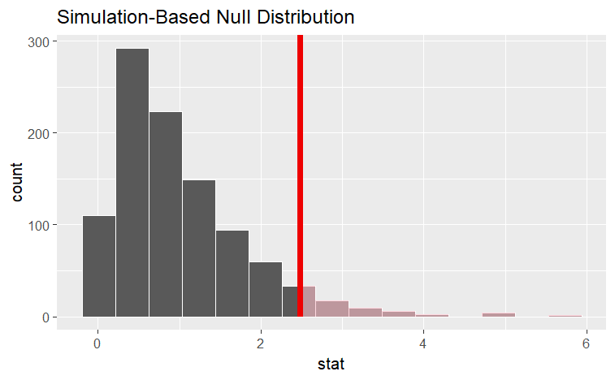

```r
visualize(null_dist) +
  shade_p_value(obs_stat = F_hat, direction = "greater")
```

# p-value

Calculating the p-value from the null distribution and observed statistic,

```r
null_dist |>
  get_p_value(obs_stat = F_hat, direction = "greater")
```

| p_value |
| --- |
| 0.049 |

The p-value is 0.05 or just about at the 95% CI level.

# Hypothesis tests

One numerical variable (mean) Calculating the observed statistic,

```r
x_bar <- gss |>
  specify(response = hours) |>
  calculate(stat = "mean")
x_bar
```

```
Response: hours (numeric)
```

| stat |
| --- |
| 41.382 |

Alternatively, using the observe() wrapper to calculate the observed statistic,

```r
x_bar <- gss |>
  observe(response = hours, stat = "mean")
```

Then, generating the null distribution,

```r
null_dist <- gss |>
  specify(response = hours) |>
  hypothesize(null = "point", mu = 40) |>
  generate(reps = 1000) |>
  calculate(stat = "mean")
glimpse(null_dist)
```

```
Rows: 1,000
Columns: 2
$ replicate <int> 1, 2, 3, 4, 5, 6, 7, 8, 9, 10, 11, 12, 13, 14, 15, 16, …
$ stat      <dbl> 38.386, 40.586, 40.128, 39.250, 40.038, 40.220, 39.788,…
```

Visualizing the observed statistic alongside the null distribution,

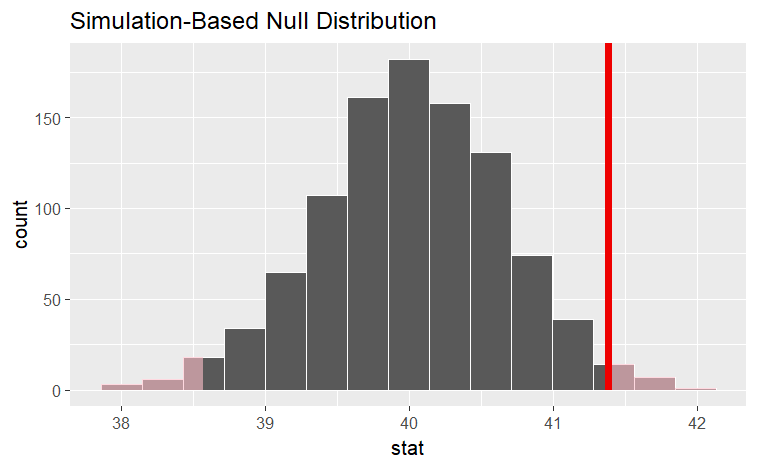

```r
visualize(null_dist) +
  shade_p_value(obs_stat = x_bar, direction = "two-sided")
```

Calculating the p-value from the null distribution and observed statistic,

```r
null_dist |>
  get_p_value(obs_stat = x_bar, direction = "two-sided")
```

| p_value |
| --- |
| 0.034 |

# One numerical variable (standardized mean t)

Calculating the observed statistic,

```r
t_bar <- gss |>
  specify(response = hours) |>
  hypothesize(null = "point", mu = 40) |>
  calculate(stat = "t")
glimpse(t_bar)
```

```
Rows: 1
Columns: 1
$ stat <dbl> 2.085191
```

Alternatively, using the `observe()` wrapper to calculate the observed statistic,

```r
t_bar <- gss |>
  observe(response = hours, null = "point", mu = 40, stat = "t")
t_bar
```

```
Response: hours (numeric)
Null Hypothesis: point
```

| stat |
| --- |
| 2.085191 |

Then, generating the null distribution,

```r
null_dist <- gss |>
  specify(response = hours) |>
  hypothesize(null = "point", mu = 40) |>
  generate(reps = 1000) |>
  calculate(stat = "t")
glimpse(null_dist)
```

```
Rows: 1,000
Columns: 2
$ replicate <int> 1, 2, 3, 4, 5, 6, 7, 8, 9, 10, 11, 12, 13, 14, 15, 16, …
$ stat      <dbl> 1.1705661, 1.5329180, -1.0468165, -1.3265543, -0.779668…
```

Alternatively, finding the null distribution using theoretical methods using the `assume()` verb,

```r
null_dist_theory <- gss |>
  specify(response = hours)  |>
  assume("t")
null_dist_theory %>% glimpse
```

```
 'infer_dist' chr "A T distribution with 499 degrees of freedom."
 - attr(*, "distribution")= chr "t"
 - attr(*, "dist_")= chr "t"
 - attr(*, "df")= num 499
 - attr(*, "distr_param")= num 499
 - attr(*, "theory_type")= chr "One sample t"
 - attr(*, "hypothesized")= logi FALSE
 - attr(*, "dots")= list()
```

Visualizing the observed statistic alongside the null distribution,

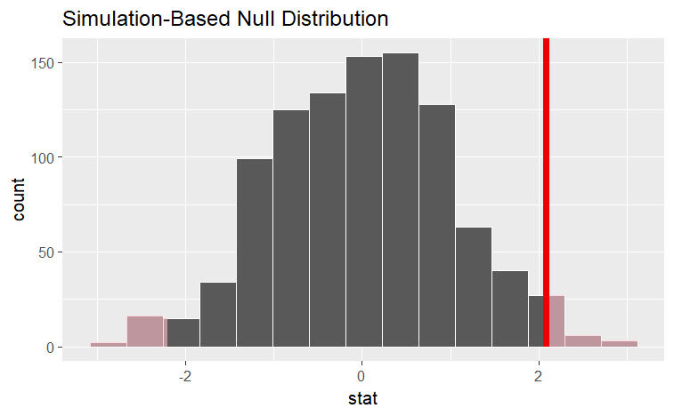

```r
visualize(null_dist) +
  shade_p_value(obs_stat = t_bar, direction = "two-sided")
```

Alternatively, visualizing the observed statistic using the theory-based null distribution,

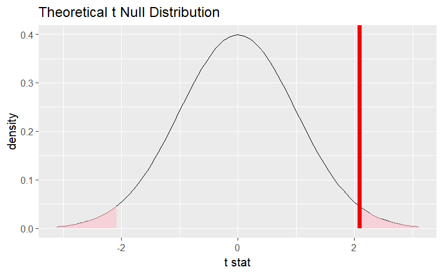

```r
visualize(null_dist_theory) +
  shade_p_value(obs_stat = t_bar, direction = "two-sided")
```

Alternatively, visualizing the observed statistic using both of the null distributions,

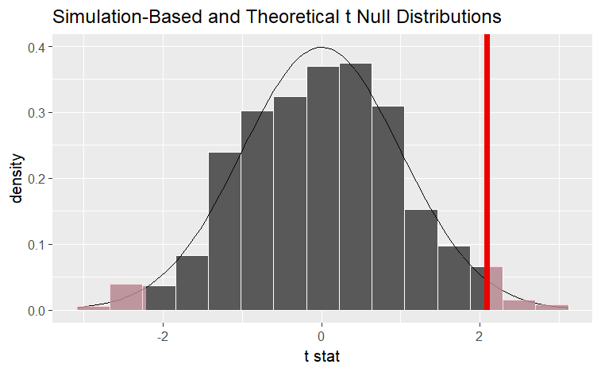

```r
visualize(null_dist, method = "both") +
  shade_p_value(obs_stat = t_bar, direction = "two-sided")
```

Note that the above code makes use of the randomization-based null distribution.

Calculating the p-value from the null distribution and observed statistic,

```r
null_dist |>
  get_p_value(obs_stat = t_bar, direction = "two-sided")
```

| p_value |
| --- |
| 0.036 |

Alternatively, using the t_test() wrapper:

```r
gss |>
  t_test(response = hours, mu = 40)
```

| statistic | t_df | p_value | alternative | estimate | lower_ci | upper_ci |
| --- | --- | --- | --- | --- | --- | --- |
| 2.085191 | 499 | 0.03755959 | two.sided | 41.382 | 40.07984 | 42.68416 |

`infer` does not support testing on one numerical variable via the z distribution.

# One numerical variable (median)

Calculating the observed statistic,

```r
x_tilde <- gss |>
  specify(response = age) |>
  calculate(stat = "median")
glimpse(x_tilde)
```

```
Rows: 1
Columns: 1
$ stat <dbl> 38
```

Alternatively, using the observe() wrapper to calculate the observed statistic,

```r
x_tilde <- gss |>
  observe(response = age, stat = "median")
x_tilde
```

```
Response: age (numeric)
```

| stat |
| --- |
| 38 |

Then, generating the null distribution,

```r
null_dist <- gss |>
  specify(response = age) |>
  hypothesize(null = "point", med = 40) |>
  generate(reps = 1000) |>
  calculate(stat = "median")
```

Visualizing the observed statistic alongside the null distribution,

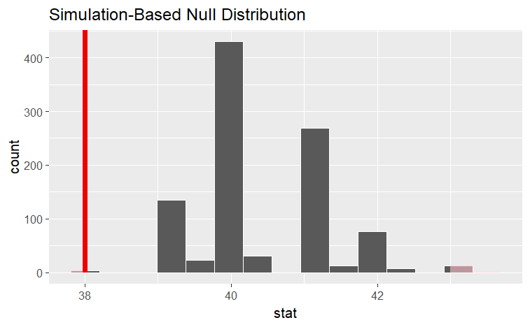

```r
visualize(null_dist) +
  shade_p_value(obs_stat = x_tilde, direction = "two-sided")
```

Calculating the p-value from the null distribution and observed statistic,

```r
null_dist |>
  get_p_value(obs_stat = x_tilde, direction = "two-sided")
```

| p_value |
| --- |
| 0.006 |

#One numerical variable (paired) The example under this header is compatible with stats “mean”, “median”, “sum”, and “sd”.

Suppose that each of these survey respondents had provided the number of hours worked per week when surveyed 5 years prior, encoded as hours_previous.

```r
set.seed(1)

gss_paired <- gss |>
   mutate(
      hours_previous = hours + 5 - rpois(nrow(gss), 4.8),
      diff = hours - hours_previous
   )

gss_paired |>
   select(hours, hours_previous, diff)
```

| hours | hours_previous | diff |
| --- | --- | --- |
| 50 | 52 | -2 |
| 31 | 32 | -1 |
| 40 | 40 | 0 |
| 40 | 37 | 3 |
| 40 | 42 | -2 |
| 53 | 50 | 3 |
| 32 | 28 | 4 |
| 20 | 19 | 1 |
| 40 | 40 | 0 |
| 40 | 43 | -3 |

[output cut: 490 more lines]

We’d like to test the null hypothesis that the “mean” hours worked per week did not change between the sampled time and five years prior.

infer supports paired hypothesis testing via the null = “paired independence” argument to hypothesize().

Calculating the observed statistic,

```r
x_tilde <- gss_paired |>
  specify(response = diff) |>
  calculate(stat = "mean")
x_tilde
```

```
Response: diff (numeric)
```

| stat |
| --- |
| -0.202 |

Alternatively, using the `observe()` wrapper to calculate the observed statistic,

```r
x_tilde <- gss_paired |>
  observe(response = diff, stat = "mean")
```

Then, generating the null distribution,

```r
null_dist <- gss_paired |>
  specify(response = diff) |>
  hypothesize(null = "paired independence") |>
  generate(reps = 1000, type = "permute") |>
  calculate(stat = "mean")
```

Note that the diff column itself is not permuted, but rather the signs of the values in the column.

Visualizing the observed statistic alongside the null distribution,

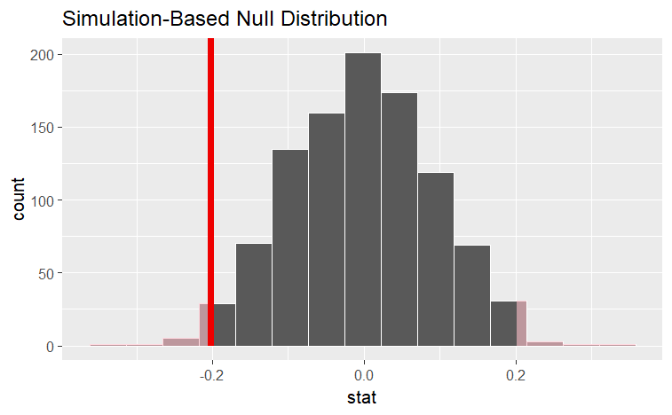

```r
visualize(null_dist) +
  shade_p_value(obs_stat = x_tilde, direction = "two-sided")
```

Calculating the p-value from the null distribution and observed statistic,

```r
null_dist |>
  get_p_value(obs_stat = x_tilde, direction = "two-sided")
```

| p_value |
| --- |
| 0.028 |

# One categorical (one proportion)

Calculating the observed statistic,

```r
p_hat <- gss |>
  specify(response = sex, success = "female") |>
  calculate(stat = "prop")
```

Alternatively, using the `observe()` wrapper to calculate the observed statistic,

```r
p_hat <- gss |>
  observe(response = sex, success = "female", stat = "prop")
```

Then, generating the null distribution,

```r
null_dist <- gss |>
  specify(response = sex, success = "female") |>
  hypothesize(null = "point", p = .5) |>
  generate(reps = 1000) |>
  calculate(stat = "prop")
```

Visualizing the observed statistic alongside the null distribution,

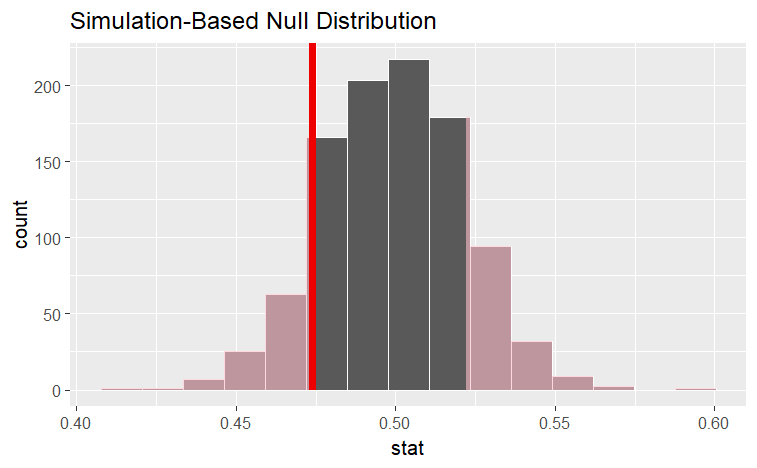

```r
visualize(null_dist) +
  shade_p_value(obs_stat = p_hat, direction = "two-sided")
```

Calculating the p-value from the null distribution and observed statistic,

```r
null_dist |>
  get_p_value(obs_stat = p_hat, direction = "two-sided")
```

| p_value |
| --- |
| 0.276 |

Note that logical variables will be coerced to factors:

```r
null_dist <- gss |>
  dplyr::mutate(is_female = (sex == "female")) |>
  specify(response = is_female, success = "TRUE") |>
  hypothesize(null = "point", p = .5) |>
  generate(reps = 1000) |>
  calculate(stat = "prop")
```

# One categorical variable (standardized proportion z)

Calculating the observed statistic,

```r
p_hat <- gss |>
  specify(response = sex, success = "female") |>
  hypothesize(null = "point", p = .5) |>
  calculate(stat = "z")
```

Alternatively, using the observe() wrapper to calculate the observed statistic,

```r
p_hat <- gss |>
  observe(response = sex, success = "female", null = "point", p = .5, stat = "z")
```

Then, generating the null distribution,

```r
null_dist <- gss |>
  specify(response = sex, success = "female") |>
  hypothesize(null = "point", p = .5) |>
  generate(reps = 1000, type = "draw") |>
  calculate(stat = "z")
```

Visualizing the observed statistic alongside the null distribution,

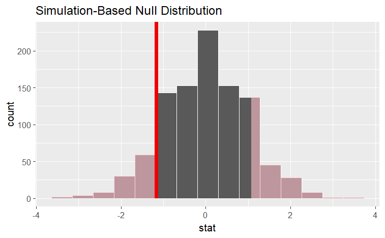

```r
visualize(null_dist) +
  shade_p_value(obs_stat = p_hat, direction = "two-sided")
```

Calculating the p-value from the null distribution and observed statistic,

```r
null_dist |>
  get_p_value(obs_stat = p_hat, direction = "two-sided")
```

| p_value |
| --- |
| 0.252 |

The package also supplies a wrapper around `prop.test()` for tests of a single proportion on tidy data.

```r
prop_test(gss,
          college ~ NULL,
          p = .2)
```

| statistic | chisq_df | p_value | alternative |
| --- | --- | --- | --- |
| 635.6281 | 1 | 2.983763e-140 | two.sided |

`infer` does not support testing two means via the z distribution.

#Two categorical (2 level) variables The `infer` package provides several statistics to work with data of this type. One of them is the statistic for difference in proportions.

Calculating the observed statistic,

```r
d_hat <- gss |>
  specify(college ~ sex, success = "no degree") |>
  calculate(stat = "diff in props", order = c("female", "male"))
```

Alternatively, using the observe() wrapper to calculate the observed statistic,

```r
d_hat <- gss |>
  observe(
    college ~ sex,
    success = "no degree",
    stat = "diff in props", order = c("female", "male")
  )
```

Then, generating the null distribution,

```r
null_dist <- gss |>
  specify(college ~ sex, success = "no degree") |>
  hypothesize(null = "independence") |>
  generate(reps = 1000) |>
  calculate(stat = "diff in props", order = c("female", "male"))
```

Visualizing the observed statistic alongside the null distribution,

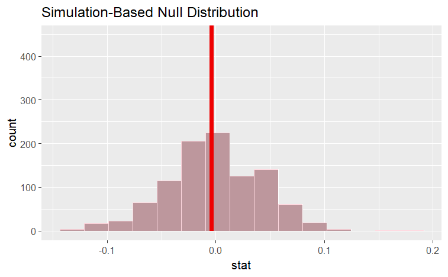

```r
visualize(null_dist) +
  shade_p_value(obs_stat = d_hat, direction = "two-sided")
```

Calculating the p-value from the null distribution and observed statistic,

```r
null_dist |>
  get_p_value(obs_stat = d_hat, direction = "two-sided")
```

| p_value |
| --- |
| 1 |

`infer` also provides functionality to calculate ratios of proportions. The workflow looks similar to that for `diff` in `props`.

Calculating the observed statistic,

```r
r_hat <- gss |>
  specify(college ~ sex, success = "no degree") |>
  calculate(stat = "ratio of props", order = c("female", "male"))
```

Alternatively, using the observe() wrapper to calculate the observed statistic,

```r
r_hat <- gss |>
  observe(college ~ sex, success = "no degree",
          stat = "ratio of props", order = c("female", "male"))
```

Then, generating the null distribution,

```r
null_dist <- gss |>
  specify(college ~ sex, success = "no degree") |>
  hypothesize(null = "independence") |>
  generate(reps = 1000) |>
  calculate(stat = "ratio of props", order = c("female", "male"))
```

Visualizing the observed statistic alongside the null distribution,

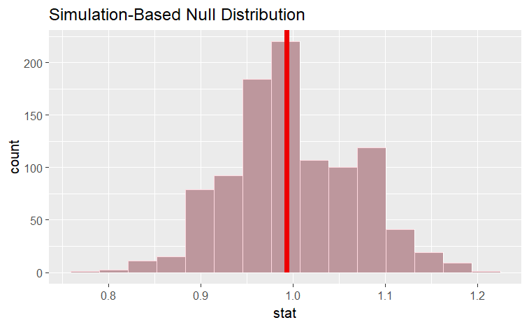

```r
visualize(null_dist) +
  shade_p_value(obs_stat = r_hat, direction = "two-sided")
```

Calculating the p-value from the null distribution and observed statistic,

```r
null_dist |>
  get_p_value(obs_stat = r_hat, direction = "two-sided")
```

| p_value |
| --- |
| 1 |

In addition, the package provides functionality to calculate odds ratios. The workflow also looks similar to that for diff in props.

Calculating the observed statistic,

```r
or_hat <- gss |>
  specify(college ~ sex, success = "no degree") |>
  calculate(stat = "odds ratio", order = c("female", "male"))
```

Then, generating the null distribution,

```r
null_dist <- gss |>
  specify(college ~ sex, success = "no degree") |>
  hypothesize(null = "independence") |>
  generate(reps = 1000) |>
  calculate(stat = "odds ratio", order = c("female", "male"))
```

Visualizing the observed statistic alongside the null distribution,

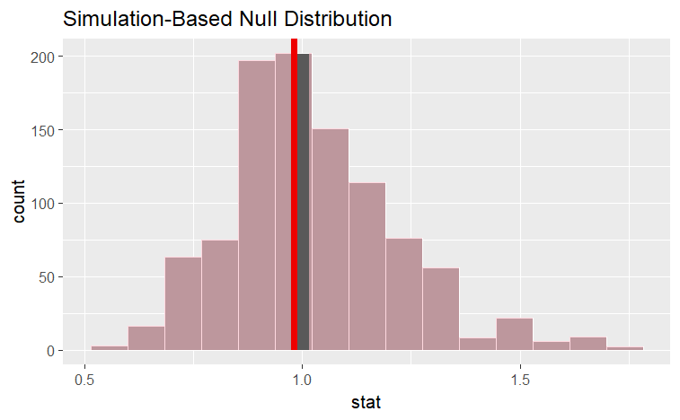

```r
visualize(null_dist) +
  shade_p_value(obs_stat = or_hat, direction = "two-sided")
```

Calculating the p-value from the null distribution and observed statistic,

```r
null_dist |>
  get_p_value(obs_stat = or_hat, direction = "two-sided")
```

| p_value |
| --- |
| 0.984 |

# Two categorical (2 level) variables (z)

Finding the standardized observed statistic,

```r
z_hat <- gss |>
  specify(college ~ sex, success = "no degree") |>
  hypothesize(null = "independence") |>
  calculate(stat = "z", order = c("female", "male"))
```

Alternatively, using the observe() wrapper to calculate the observed statistic,

```r
z_hat <- gss |>
  observe(college ~ sex, success = "no degree",
          stat = "z", order = c("female", "male"))
```

Then, generating the null distribution,

```r
null_dist <- gss |>
  specify(college ~ sex, success = "no degree") |>
  hypothesize(null = "independence") |>
  generate(reps = 1000) |>
  calculate(stat = "z", order = c("female", "male"))
```

Alternatively, finding the null distribution using theoretical methods using the `assume()` verb,

```r
null_dist_theory <- gss |>
  specify(college ~ sex, success = "no degree") |>
  assume("z")
```

Visualizing the observed statistic alongside the null distribution,

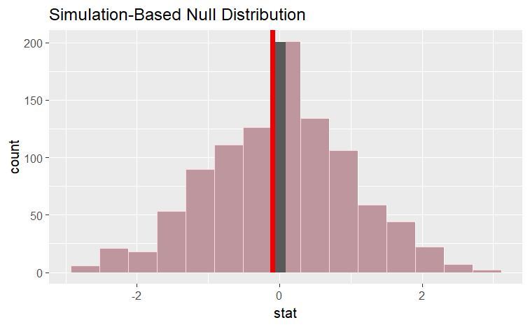

```r
visualize(null_dist) +
  shade_p_value(obs_stat = z_hat, direction = "two-sided")
```

Alternatively, visualizing the observed statistic using the theory-based null distribution,

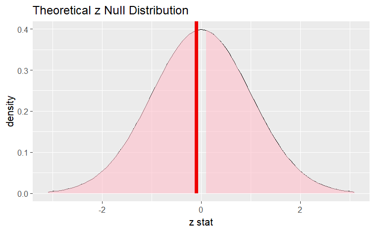

```r
visualize(null_dist_theory) +
  shade_p_value(obs_stat = z_hat, direction = "two-sided")
```

Alternatively, visualizing the observed statistic using both of the null distributions,

```r
visualize(null_dist, method = "both") +
  shade_p_value(obs_stat = z_hat, direction = "two-sided")
```

[output not shown]

Note that the above code makes use of the randomization-based null distribution.

Calculating the p-value from the null distribution and observed statistic,

```r
null_dist |>
  get_p_value(obs_stat = z_hat, direction = "two-sided")
```

| p_value |
| --- |
| 0.98 |

Note the similarities in this plot and the previous one.

The package also supplies a wrapper around `prop.test` to allow for tests of equality of proportions on tidy data.

```r
prop_test(gss,
          college ~ sex,
          order = c("female", "male"))
```

| statistic | chisq_df | p_value | alternative | lower_ci | upper_ci |
| --- | --- | --- | --- | --- | --- |
| 2.036393e-05 | 1 | 0.9963994 | two.sided | -0.09184261 | 0.08343588 |

#One categorical (>2 level) - GoF Calculating the observed statistic,

Note the need to add in the hypothesized values here to compute the observed statistic.

```r
Chisq_hat <- gss |>
  specify(response = finrela) |>
  hypothesize(
    null = "point",
    p = c(
      "far below average" = 1 / 6,
      "below average" = 1 / 6,
      "average" = 1 / 6,
      "above average" = 1 / 6,
      "far above average" = 1 / 6,
      "DK" = 1 / 6
    )
  ) |>
  calculate(stat = "Chisq")
```

Alternatively, using the observe() wrapper to calculate the observed statistic,

```r
Chisq_hat <- gss |>
  observe(
    response = finrela,
    null = "point",
    p = c(
      "far below average" = 1 / 6,
      "below average" = 1 / 6,
      "average" = 1 / 6,
      "above average" = 1 / 6,
      "far above average" = 1 / 6,
      "DK" = 1 / 6
    ),
    stat = "Chisq"
  )
```

Then, generating the null distribution,

```r
null_dist <- gss |>
  specify(response = finrela) |>
  hypothesize(
    null = "point",
    p = c(
      "far below average" = 1 / 6,
      "below average" = 1 / 6,
      "average" = 1 / 6,
      "above average" = 1 / 6,
      "far above average" = 1 / 6,
      "DK" = 1 / 6
    )
  ) |>
  generate(reps = 1000, type = "draw") |>
  calculate(stat = "Chisq")
```

Alternatively, finding the null distribution using theoretical methods using the `assume()` verb,

```r
null_dist_theory <- gss |>
  specify(response = finrela) |>
  assume("Chisq")
```

Visualizing the observed statistic alongside the null distribution,

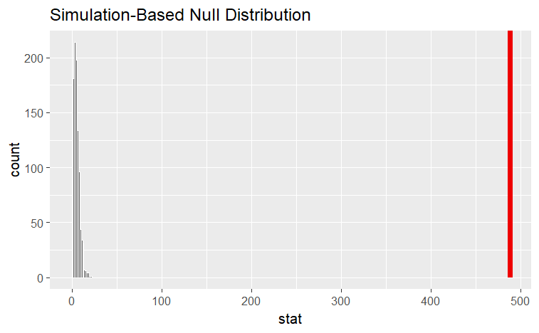

```r
visualize(null_dist) +
  shade_p_value(obs_stat = Chisq_hat, direction = "greater")
```

Alternatively, visualizing the observed statistic using the theory-based null distribution,

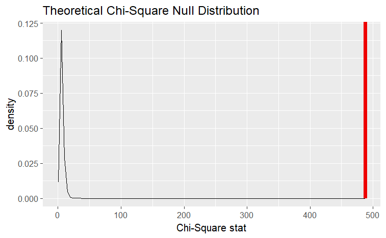

```r
visualize(null_dist_theory) +
  shade_p_value(obs_stat = Chisq_hat, direction = "greater")
```

[figure not shown]

```r
visualize(null_dist_theory, method = "both") +
  shade_p_value(obs_stat = Chisq_hat, direction = "greater")
```

Calculating the p-value from the null distribution and observed statistic,

```r
null_dist |>
  get_p_value(obs_stat = Chisq_hat, direction = "greater")
```

| p_value |
| --- |
| 0 |

Alternatively, using the chisq_test wrapper:

```r
chisq_test(
  gss,
  response = finrela,
  p = c(
    "far below average" = 1 / 6,
    "below average" = 1 / 6,
    "average" = 1 / 6,
    "above average" = 1 / 6,
    "far above average" = 1 / 6,
    "DK" = 1 / 6
  )
)
```

| statistic | chisq_df | p_value |
| --- | --- | --- |
| 487.984 | 5 | 3.131231e-103 |

#Two categorical (>2 level): Chi-squared test of independence Calculating the observed statistic,

```r
Chisq_hat <- gss |>
  specify(formula = finrela ~ sex) |>
  hypothesize(null = "independence") |>
  calculate(stat = "Chisq")
```

Alternatively, using the observe() wrapper to calculate the observed statistic,

```r
Chisq_hat <- gss |>
  observe(formula = finrela ~ sex, stat = "Chisq")
```

Then, generating the null distribution,

```r
null_dist <- gss |>
  specify(finrela ~ sex) |>
  hypothesize(null = "independence") |>
  generate(reps = 1000, type = "permute") |>
  calculate(stat = "Chisq")
```

Alternatively, finding the null distribution using theoretical methods using the `assume()` verb,

```r
null_dist_theory <- gss |>
  specify(finrela ~ sex) |>
  assume(distribution = "Chisq")
```

Visualizing the observed statistic alongside the null distribution,

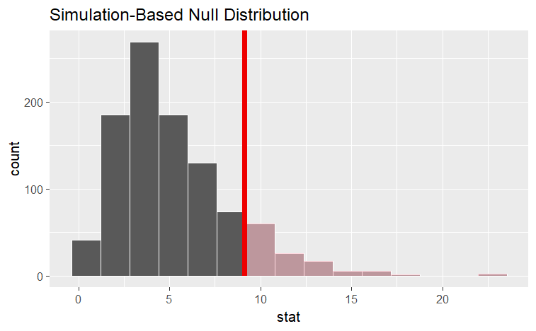

```r
visualize(null_dist) +
  shade_p_value(obs_stat = Chisq_hat, direction = "greater")
```

Alternatively, visualizing the observed statistic using the theory-based null distribution,

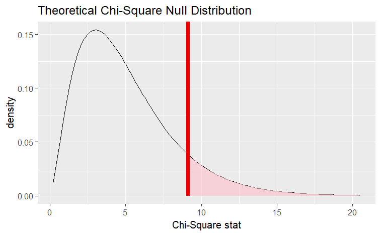

```r
visualize(null_dist_theory) +
  shade_p_value(obs_stat = Chisq_hat, direction = "greater")
```

Alternatively, visualizing the observed statistic using both of the null distributions,

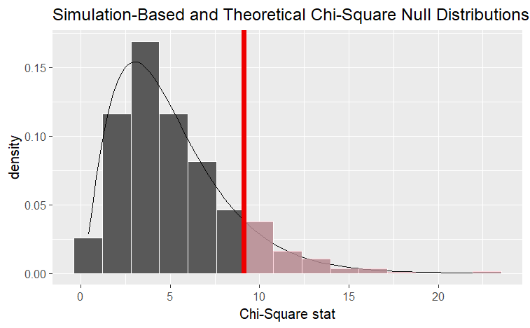

```r
visualize(null_dist, method = "both") +
  shade_p_value(obs_stat = Chisq_hat, direction = "greater")
```

Note that the above code makes use of the randomization-based null distribution.

Calculating the p-value from the null distribution and observed statistic,

```r
null_dist |>
  get_p_value(obs_stat = Chisq_hat, direction = "greater")
```

| p_value |
| --- |
| 0.118 |

Alternatively, using the wrapper to carry out the test,

```r
gss |>
  chisq_test(formula = finrela ~ sex)
```

| statistic | chisq_df | p_value |
| --- | --- | --- |
| 9.105397 | 5 | 0.1049333 |

# One numerical variable, one categorical (2 levels) (diff in means)

Calculating the observed statistic,

```r
d_hat <- gss |>
  specify(age ~ college) |>
  calculate(stat = "diff in means", order = c("degree", "no degree"))
```

Alternatively, using the observe() wrapper to calculate the observed statistic,

```r
d_hat <- gss |>
  observe(age ~ college,
          stat = "diff in means", order = c("degree", "no degree"))
```

Then, generating the null distribution,

```r
null_dist <- gss |>
  specify(age ~ college) |>
  hypothesize(null = "independence") |>
  generate(reps = 1000, type = "permute") |>
  calculate(stat = "diff in means", order = c("degree", "no degree"))
```

Visualizing the observed statistic alongside the null distribution,

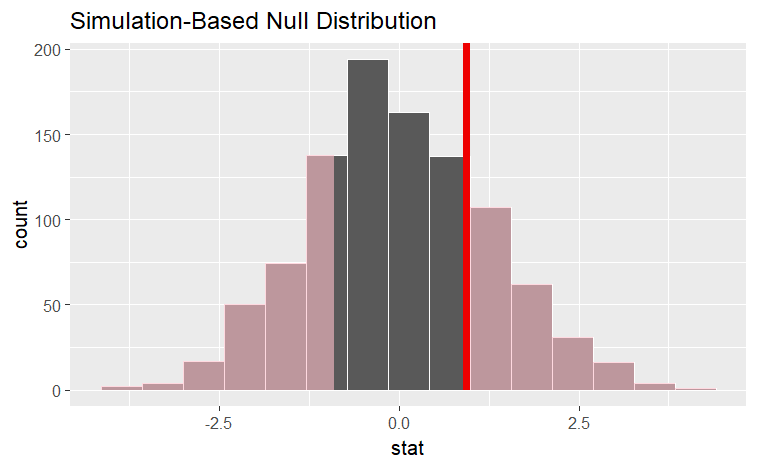

```r
visualize(null_dist) +
  shade_p_value(obs_stat = d_hat, direction = "two-sided")
```

Calculating the p-value from the null distribution and observed statistic,

```r
null_dist |>
  get_p_value(obs_stat = d_hat, direction = "two-sided")
```

| p_value |
| --- |
| 0.46 |

# One numerical variable, one categorical (2 levels) (t)

Finding the standardized observed statistic, alternatively, using the observe() wrapper to calculate the observed statistic,

```r
t_hat <- gss |>
  specify(age ~ college) |>
  hypothesize(null = "independence") |>
  calculate(stat = "t", order = c("degree", "no degree"))

t_hat <- gss |>
  observe(age ~ college,
          stat = "t", order = c("degree", "no degree"))
```

Then, generating the null distribution, alternatively, finding the null distribution using theoretical methods using the assume() verb,

```r
null_dist <- gss |>
  specify(age ~ college) |>
  hypothesize(null = "independence") |>
  generate(reps = 1000, type = "permute") |>
  calculate(stat = "t", order = c("degree", "no degree"))
null_dist_theory <- gss |>
  specify(age ~ college) |>
  assume("t")
```

Visualizing the observed statistic alongside the null distribution, Alternatively, visualizing the observed statistic using the theory-based null distribution, Alternatively, visualizing the observed statistic using the theory-based null distribution, Alternatively, visualizing the observed statistic using both of the null distributions,

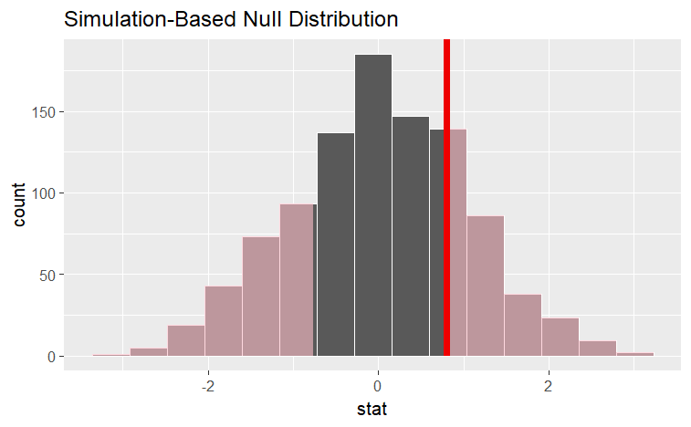

```r
visualize(null_dist) +
  shade_p_value(obs_stat = t_hat, direction = "two-sided")
```

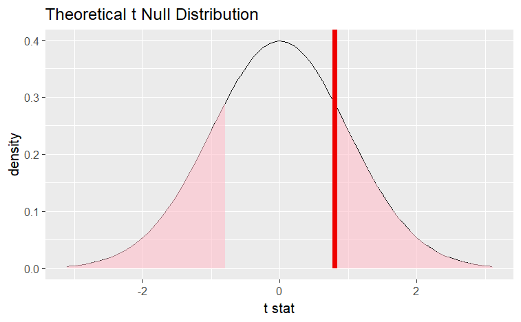

```r
visualize(null_dist_theory) +
  shade_p_value(obs_stat = t_hat, direction = "two-sided")
```

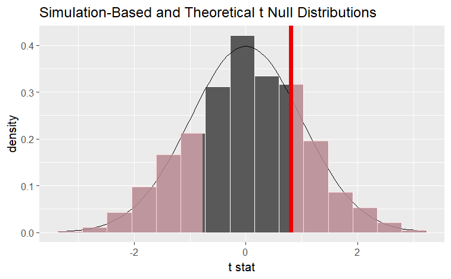

```r
visualize(null_dist, method = "both") +
  shade_p_value(obs_stat = t_hat, direction = "two-sided")
```

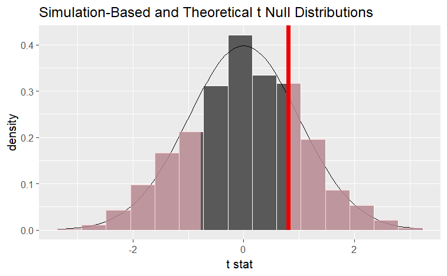

```r
visualize(null_dist, method = "both") +
  shade_p_value(obs_stat = t_hat, direction = "two-sided")
```

Note that the above code makes use of the randomization-based null distribution.

Calculating the p-value from the null distribution and observed statistic,

```r
null_dist |>
  get_p_value(obs_stat = t_hat, direction = "two-sided")
```

| p_value |
| --- |
| 0.442 |

Note the similarities in this plot and the previous one.

# One numerical variable, one categorical (2 levels) (diff in medians)

Calculating the observed statistic, Alternatively, using the observe() wrapper to calculate the observed statistic,

```r
d_hat <- gss |>
  specify(age ~ college) |>
  calculate(stat = "diff in medians", order = c("degree", "no degree"))

d_hat <- gss |>
  observe(age ~ college,
          stat = "diff in medians", order = c("degree", "no degree"))
```

Then, generating the null distribution,

```r
null_dist <- gss |>
  specify(age ~ college) |> # alt: response = age, explanatory = season
  hypothesize(null = "independence") |>
  generate(reps = 1000, type = "permute") |>
  calculate(stat = "diff in medians", order = c("degree", "no degree"))
```

Visualizing the observed statistic alongside the null distribution,

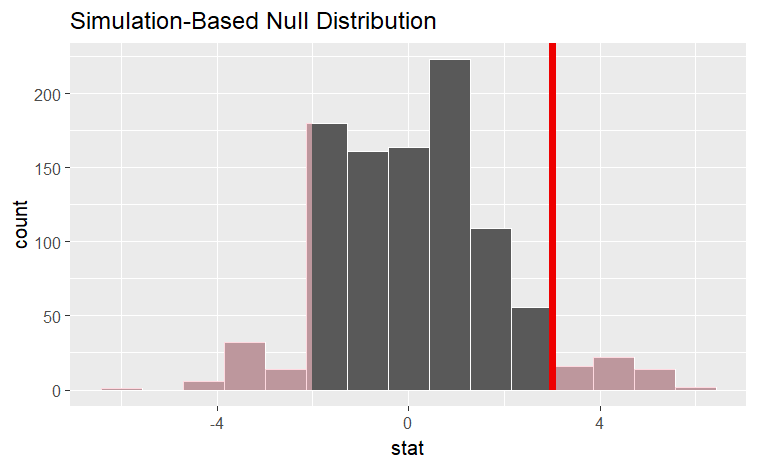

```r
visualize(null_dist) +
  shade_p_value(obs_stat = d_hat, direction = "two-sided")
```

Calculating the p-value from the null distribution and observed statistic,

```r
null_dist |>
  get_p_value(obs_stat = d_hat, direction = "two-sided")
```

| p_value |
| --- |
| 0.172 |

# One numerical, one categorical (>2 levels) - ANOVA

Calculating the observed statistic, Alternatively, using the observe() wrapper to calculate the observed statistic,

```r
F_hat <- gss |>
  specify(age ~ partyid) |>
  calculate(stat = "F")


F_hat <- gss |>
  observe(age ~ partyid, stat = "F")
```

Then, generating the null distribution, Alternatively, finding the null distribution using theoretical methods using the assume() verb,

```r
null_dist <- gss |>
   specify(age ~ partyid) |>
   hypothesize(null = "independence") |>
   generate(reps = 1000, type = "permute") |>
   calculate(stat = "F")
null_dist_theory <- gss |>
   specify(age ~ partyid) |>
   hypothesize(null = "independence") |>
   assume(distribution = "F")
```

Visualizing the observed statistic alongside the null distribution, Alternatively, visualizing the observed statistic using the theory-based null distribution, Alternatively, visualizing the observed statistic using both of the null distributions,

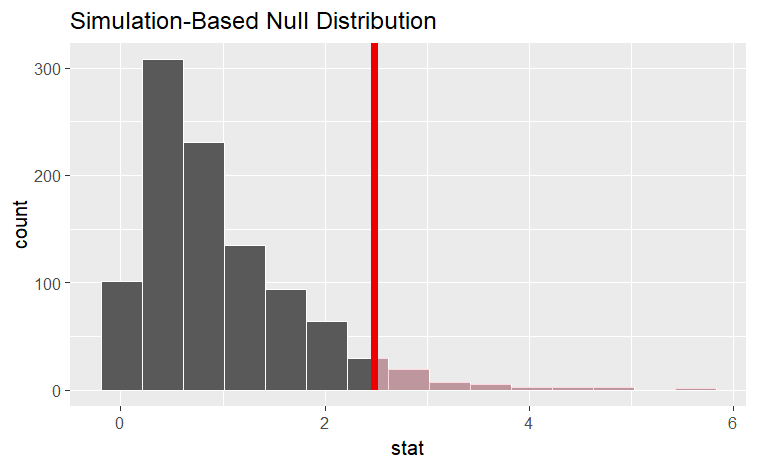

```r
visualize(null_dist) +
  shade_p_value(obs_stat = F_hat, direction = "greater")
```

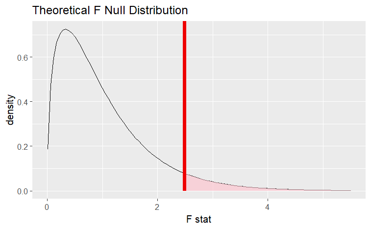

```r
visualize(null_dist_theory) +
  shade_p_value(obs_stat = F_hat, direction = "greater")
```

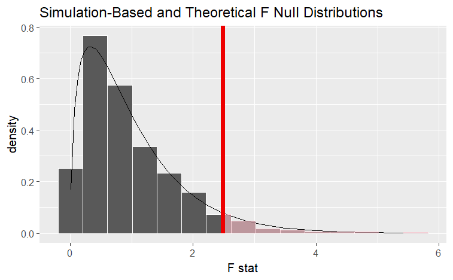

```r
visualize(null_dist, method = "both") +
  shade_p_value(obs_stat = F_hat, direction = "greater")
```

Note that the above code makes use of the randomization-based null distribution.

Calculating the p-value from the null distribution and observed statistic,

```r
null_dist |>
  get_p_value(obs_stat = F_hat, direction = "greater")
```

| p_value |
| --- |
| 0.045 |

```r
## # A tibble: 1 × 1
##   p_value
##     <dbl>
## 1   0.045
```

# Two numerical vars - SLR

Calculating the observed statistic, Alternatively, using the observe() wrapper to calculate the observed statistic,

```r
slope_hat <- gss |>
  specify(hours ~ age) |>
  calculate(stat = "slope")
slope_hat <- gss |>
  observe(hours ~ age, stat = "slope")
```

Then, generating the null distribution,

```r
null_dist <- gss |>
   specify(hours ~ age) |>
   hypothesize(null = "independence") |>
   generate(reps = 1000, type = "permute") |>
   calculate(stat = "slope")
```

Visualizing the observed statistic alongside the null distribution,

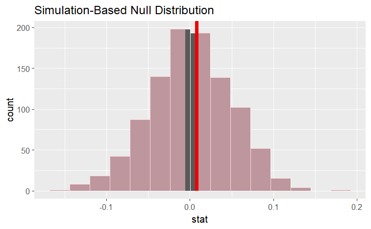

```r
visualize(null_dist) +
  shade_p_value(obs_stat = slope_hat, direction = "two-sided")
```

Calculating the p-value from the null distribution and observed statistic,

```r
null_dist |>
  get_p_value(obs_stat = slope_hat, direction = "two-sided")
```

| p_value |
| --- |
| 0.902 |

#Two numerical vars - correlation Calculating the observed statistic, Alternatively, using the observe() wrapper to calculate the observed statistic,

```r
correlation_hat <- gss |>
  specify(hours ~ age) |>
  calculate(stat = "correlation")
correlation_hat <- gss |>
  observe(hours ~ age, stat = "correlation")
```

Then, generating the null distribution,

```r
null_dist <- gss |>
   specify(hours ~ age) |>
   hypothesize(null = "independence") |>
   generate(reps = 1000, type = "permute") |>
   calculate(stat = "correlation")
```

Visualizing the observed statistic alongside the null distribution,

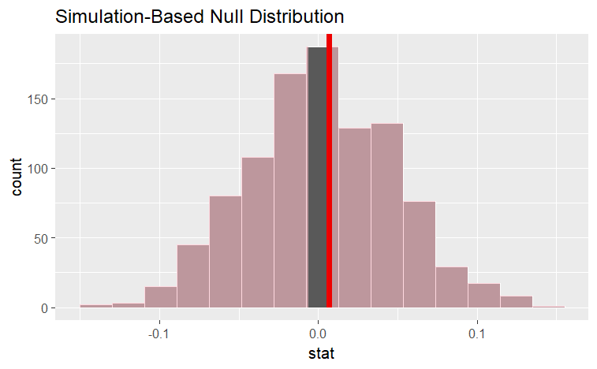

```r
visualize(null_dist) +
  shade_p_value(obs_stat = correlation_hat, direction = "two-sided")
```

Calculating the p-value from the null distribution and observed statistic,

```r
null_dist |>
  get_p_value(obs_stat = correlation_hat, direction = "two-sided")
```

| p_value |
| --- |
| 0.878 |

# Two numerical vars - SLR (t)

Not currently implemented since t could refer to standardized slope or standardized correlation.

# Multiple explanatory variables

Calculating the observed fit,

```r
obs_fit <- gss |>
  specify(hours ~ age + college) |>
  fit()
```

Generating a distribution of fits with the response variable permuted,

```r
null_dist <- gss |>
  specify(hours ~ age + college) |>
  hypothesize(null = "independence") |>
  generate(reps = 1000, type = "permute") |>
  fit()
```

Generating a distribution of fits where each explanatory variable is permuted independently,

```r
null_dist2 <- gss |>
  specify(hours ~ age + college) |>
  hypothesize(null = "independence") |>
  generate(reps = 1000, type = "permute", variables = c(age, college)) |>
  fit()
```

Visualizing the observed fit alongside the null fits,

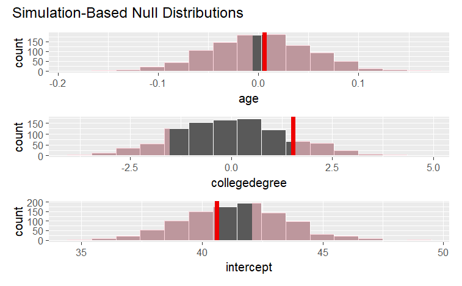

```r
visualize(null_dist) +
  shade_p_value(obs_stat = obs_fit, direction = "two-sided")
```

Calculating p-values from the null distribution and observed fit,

```r
null_dist |>
  get_p_value(obs_stat = obs_fit, direction = "two-sided")
```

| term | p_value |
| --- | --- |
| age | 0.914 |
| collegedegree | 0.266 |
| intercept | 0.734 |

```r
## # A tibble: 3 × 2
##   term          p_value
##   <chr>           <dbl>
## 1 age             0.914
## 2 collegedegree   0.266
## 3 intercept       0.734
```

Note that this `fit()`-based workflow can be applied to use cases with differing numbers of explanatory variables and explanatory variable types.